# Mixed Models: Basics

## Example: Student GPA

Load up and inspect the data.

```r
library(tidyverse)
```

```r
load('data/gpa.RData')
gpa
```

| student | occas | gpa | job | sex | highgpa | admitted | year | semester | occasion |
| --- | --- | --- | --- | --- | --- | --- | --- | --- | --- |
| 1 | year 1 semester 1 | 2.3 | 2 hours | female | 2.8 | yes | 1 | 1 | 0 |
| 1 | year 1 semester 2 | 2.1 | 2 hours | female | 2.8 | yes | 1 | 2 | 1 |
| 1 | year 2 semester 1 | 3.0 | 2 hours | female | 2.8 | yes | 2 | 1 | 2 |
| 1 | year 2 semester 2 | 3.0 | 2 hours | female | 2.8 | yes | 2 | 2 | 3 |
| 1 | year 3 semester 1 | 3.0 | 2 hours | female | 2.8 | yes | 3 | 1 | 4 |
| 1 | year 3 semester 2 | 3.3 | 2 hours | female | 2.8 | yes | 3 | 2 | 5 |
| 2 | year 1 semester 1 | 2.2 | 2 hours | male | 2.5 | no | 1 | 1 | 0 |
| 2 | year 1 semester 2 | 2.5 | 3 hours | male | 2.5 | no | 1 | 2 | 1 |
| 2 | year 2 semester 1 | 2.6 | 2 hours | male | 2.5 | no | 2 | 1 | 2 |
| 2 | year 2 semester 2 | 2.6 | 2 hours | male | 2.5 | no | 2 | 2 | 3 |

[output cut: 990 more lines]

## Application

### Standard Regression

We’ll start with a standard linear regression model. We have coefficients for the intercept and the effect of time, and in addition, the variance of the observations (residual standard error).

```r
gpa_lm = lm(gpa ~ occasion, data=gpa)
summary(gpa_lm)
```

```
Call:
lm(formula = gpa ~ occasion, data = gpa)

Residuals:
     Min       1Q   Median       3Q      Max
-0.90553 -0.22447 -0.01184  0.26921  1.19447

Coefficients:
            Estimate Std. Error t value Pr(>|t|)
(Intercept) 2.599214   0.017846  145.65   <2e-16 ***
occasion    0.106314   0.005894   18.04   <2e-16 ***
---
Signif. codes:  0 ‘***’ 0.001 ‘**’ 0.01 ‘*’ 0.05 ‘.’ 0.1 ‘ ’ 1

Residual standard error: 0.3487 on 1198 degrees of freedom
Multiple R-squared:  0.2136,    Adjusted R-squared:  0.2129
F-statistic: 325.3 on 1 and 1198 DF,  p-value: < 2.2e-16
```

### Mixed Model

```r
library(lme4)
gpa_mixed = lmer(gpa ~ occasion + (1|student), data=gpa)
summary(gpa_mixed)
```

```
Linear mixed model fit by REML ['lmerMod']
Formula: gpa ~ occasion + (1 | student)
   Data: gpa

REML criterion at convergence: 408.9

Scaled residuals:
    Min      1Q  Median      3Q     Max
-3.6169 -0.6373 -0.0004  0.6361  2.8310

Random effects:
 Groups   Name        Variance Std.Dev.
 student  (Intercept) 0.06372  0.2524
 Residual             0.05809  0.2410
Number of obs: 1200, groups:  student, 200

Fixed effects:
            Estimate Std. Error t value
(Intercept) 2.599214   0.021696   119.8
occasion    0.106314   0.004074    26.1

Correlation of Fixed Effects:
         (Intr)
occasion -0.469
```

[As a test, replace `1|student` with `1|sample(1:10, 1200, replace = T)`. As your variance due to arbitrary grouping is essentially 0, the residual error estimate is similar to the `lm` model.]

```r
confint(gpa_mixed)
```

```
Computing profile confidence intervals ...
```

```
                 2.5 %    97.5 %
.sig01      0.22517423 0.2824604
.sigma      0.23071113 0.2518510
(Intercept) 2.55665145 2.6417771
occasion    0.09832589 0.1143027
```

#### Estimated Random Effects

Now examine the random effects.

```r
ranef(gpa_mixed)$student
```

|  | (Intercept) |
| --- | --- |
| 1 | -0.070894923 |
| 2 | -0.215578440 |
| 3 | 0.088256945 |
| 4 | -0.186641736 |
| 5 | 0.030383538 |
| 6 | -0.302388550 |
| 7 | -0.143236681 |
| 8 | 0.218472110 |
| 9 | 0.102725297 |
| 10 | 0.015915187 |

[output cut: 190 more lines]

```r
coef(gpa_mixed)$student
```

|  | (Intercept) | occasion |
| --- | --- | --- |
| 1 | 2.528319 | 0.1063143 |
| 2 | 2.383636 | 0.1063143 |
| 3 | 2.687471 | 0.1063143 |
| 4 | 2.412573 | 0.1063143 |
| 5 | 2.629598 | 0.1063143 |
| 6 | 2.296826 | 0.1063143 |
| 7 | 2.455978 | 0.1063143 |
| 8 | 2.817686 | 0.1063143 |
| 9 | 2.701940 | 0.1063143 |
| 10 | 2.615129 | 0.1063143 |

[output cut: 190 more lines]

As we didn’t allow the occasion effect to vary, it is constant. We’ll change this later.

#### Prediction

```r
predict(gpa_mixed, re.form=NA) %>% head
```

```
       1        2        3        4        5        6
2.599214 2.705529 2.811843 2.918157 3.024471 3.130786
```

## Adding a Cluster-level Covariate

See exercises.

## Exercises

### Sleep

For this exercise, we’ll use the sleep study data from the `lme4` package. The following describes it.

> The average reaction time per day for subjects in a sleep deprivation study. On day 0 the subjects had their normal amount of sleep. Starting that night they were restricted to 3 hours of sleep per night. The observations represent the average reaction time (in milliseconds) on a series of tests given each day to each subject.

After loading the package, the data can be loaded as follows. I show the first few observations.

```r
library(lme4)
data("sleepstudy")
head(sleepstudy)
```

|  | Reaction | Days | Subject |
| --- | --- | --- | --- |
| 1 | 249.5600 | 0 | 308 |
| 2 | 258.7047 | 1 | 308 |
| 3 | 250.8006 | 2 | 308 |
| 4 | 321.4398 | 3 | 308 |
| 5 | 356.8519 | 4 | 308 |
| 6 | 414.6901 | 5 | 308 |

1. Run a regression with Reaction as the target variable and Days as the predictor.
2. Run a mixed model with a random intercept for Subject.
3. Interpret the variance components and fixed effects.
4. What would a plot of the prediction lines per student look like relative to the overall trend?

### Cluster level covariate

Rerun the mixed model with the GPA data adding the cluster level covariate of `sex`, or high school GPA (`highgpa`), or both. Interpret all aspects of the results.

```r
gpa_mixed_cluster_level = lmer(?, gpa)

summary(gpa_mixed_cluster_level)
```

What happened to the student variance after adding cluster level covariates to the model?

### Simulation

The following represents a simple way to simulate a random intercepts model. Note each object what each object is, and make sure the code make sense to you. Then run it.

```r
set.seed(1234)  # this will allow you to exactly duplicate your result
Ngroups = 100
NperGroup = 3
N = Ngroups * NperGroup
groups = factor(rep(1:Ngroups, each = NperGroup))
u = rnorm(Ngroups, sd = .5)
e = rnorm(N, sd = .25)
x = rnorm(N)
y = 2 + .5 * x + u[groups] + e

d = data.frame(x, y, groups)
```

Which of the above represent the fixed and random effects? Now run the following.

```r
model = lmer(y ~ x + (1|groups), data=d)
summary(model)
```

```
Linear mixed model fit by REML ['lmerMod']
Formula: y ~ x + (1 | groups)
   Data: d

REML criterion at convergence: 276.6

Scaled residuals:
     Min       1Q   Median       3Q      Max
-2.28382 -0.54016 -0.03464  0.54466  2.46986

Random effects:
 Groups   Name        Variance Std.Dev.
 groups   (Intercept) 0.22908  0.4786
 Residual             0.06254  0.2501
Number of obs: 300, groups:  groups, 100

Fixed effects:
            Estimate Std. Error t value
(Intercept)  1.93788    0.05001   38.75
x            0.50747    0.01752   28.97

Correlation of Fixed Effects:
  (Intr)
x 0.029
```

```r
confint(model)
```

```
Computing profile confidence intervals ...
```

```
                2.5 %    97.5 %
.sig01      0.4108568 0.5568699
.sigma      0.2268842 0.2760810
(Intercept) 1.8394120 2.0363239
x           0.4731324 0.5419848
```

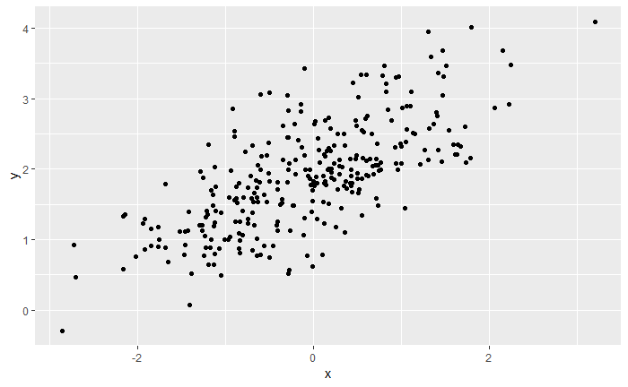

```r
library(ggplot2)
ggplot(aes(x, y), data=d) +
  geom_point()
```

Do the results seem in keeping with what you expect?

In what follows we’ll change various aspects of the data, then rerun the model after each change, then summarize and get confidence intervals as before. For each note specifically at least one thing that changed in the results.

0. First calculate or simply eyeball the intraclass correlation coefficient:

$$\frac{\textrm{random effect variance}}{\textrm{residual + random effect variance}}$$

In addition, create a density plot of the random effects as follows.

```r
re = ranef(model)$groups
qplot(x=re, geom='density', xlim=c(-3,3))
```

1. Change the random effect variance/sd and/or the residual variance/sd and note your new estimate of the ICC, and plot the random effect as before.
2. Reset the values to the original. Change Ngroups to 50. What differences do you see in the confidence interval estimates?
3. Set the Ngroups back to 100. Now change NperGroup to 10, and note again the how the CI is different from the base condition.